### Mulitple Regression from WHO data

```r
library(tidyverse)
library(knitr)
library(kableExtra)
url = "https://raw.githubusercontent.com/josh1den/DATA-605/main/HW/HW12/who.csv"
df = read.csv(url)
kable(head(df), align="c") |>
  kable_styling(bootstrap_options = c("striped", "hover", "condensed"))
```

| Country | LifeExp | InfantSurvival | Under5Survival | TBFree | PropMD | PropRN | PersExp | GovtExp | TotExp |
| --- | --- | --- | --- | --- | --- | --- | --- | --- | --- |
| Afghanistan | 42 | 0.835 | 0.743 | 0.99769 | 0.0002288 | 0.0005723 | 20 | 92 | 112 |
| Albania | 71 | 0.985 | 0.983 | 0.99974 | 0.0011431 | 0.0046144 | 169 | 3128 | 3297 |
| Algeria | 71 | 0.967 | 0.962 | 0.99944 | 0.0010605 | 0.0020914 | 108 | 5184 | 5292 |
| Andorra | 82 | 0.997 | 0.996 | 0.99983 | 0.0032973 | 0.0035000 | 2589 | 169725 | 172314 |
| Angola | 41 | 0.846 | 0.740 | 0.99656 | 0.0000704 | 0.0011462 | 36 | 1620 | 1656 |
| Antigua and Barbuda | 73 | 0.990 | 0.989 | 0.99991 | 0.0001429 | 0.0027738 | 503 | 12543 | 13046 |

```r
names(df)
```

```
##  [1] "Country"        "LifeExp"        "InfantSurvival" "Under5Survival"
##  [5] "TBFree"         "PropMD"         "PropRN"         "PersExp"
##  [9] "GovtExp"        "TotExp"
```

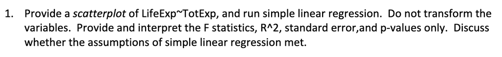

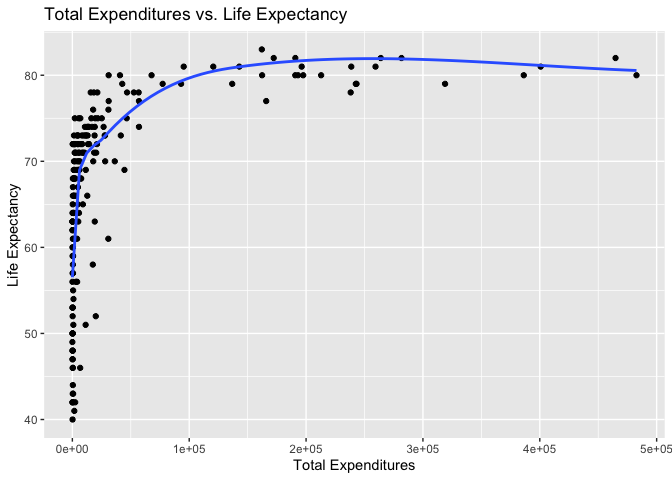

```r
ggplot(df, aes(x=TotExp, y=LifeExp)) +
  geom_point() +
  geom_smooth(se=FALSE) +
  labs(title = "Total Expenditures vs. Life Expectancy", x="Total Expenditures", y="Life Expectancy")
```

```r
df.lm1 = lm(LifeExp ~ TotExp, df)
summary(df.lm1)
```

```
##
## Call:
## lm(formula = LifeExp ~ TotExp, data = df)
##
## Residuals:
##     Min      1Q  Median      3Q     Max
## -24.764  -4.778   3.154   7.116  13.292
##
## Coefficients:
##              Estimate Std. Error t value Pr(>|t|)
## (Intercept) 6.475e+01  7.535e-01  85.933  < 2e-16 ***
## TotExp      6.297e-05  7.795e-06   8.079 7.71e-14 ***
## ---
## Signif. codes:  0 '***' 0.001 '**' 0.01 '*' 0.05 '.' 0.1 ' ' 1
##
## Residual standard error: 9.371 on 188 degrees of freedom
## Multiple R-squared:  0.2577, Adjusted R-squared:  0.2537
## F-statistic: 65.26 on 1 and 188 DF,  p-value: 7.714e-14
```

The **F-statistic** compares variable fits in multiple regression models. Since this is a single-intercept model, the f-statistic is not meaningful.

The **R-squared** of 0.25 indicates Total Expenditures accounts for only 25% of the variance in Life Expectancy. This is very low.

The **Standard Error** of 7.535e-01 for the intercept and 7.795e-06 for the slope are small relative to the coefficients, which suggests low variability among the parameters.

The **P-value** of 7.71e-14 is very small and significant. This means there is a high probability total expenditures is relevant to life expectancy.

The takeaway is total expenditures is relevant life expectancy, but doesn’t fully explain it. More is needed.

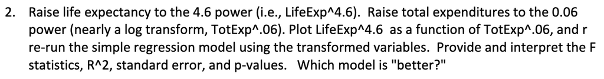

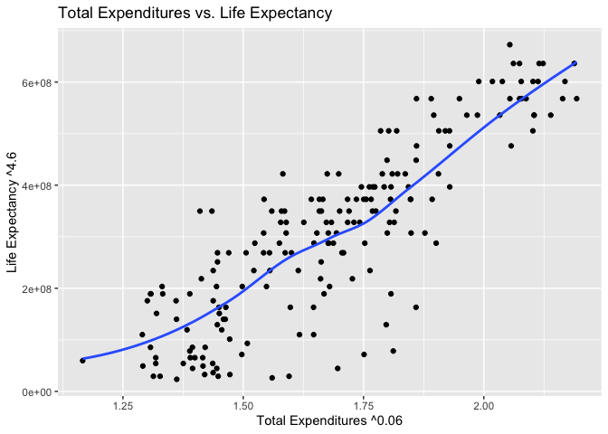

```r
ggplot(df, aes(x=TotExp^0.06, y=LifeExp^4.6)) +
  geom_point() +
  geom_smooth(se=FALSE) +
  labs(title = "Total Expenditures vs. Life Expectancy", x="Total Expenditures ^0.06", y="Life Expectancy ^4.6")
```

```r
df.lm2 = lm(I(LifeExp^4.6) ~ I(TotExp^0.06), df)
summary(df.lm2)
```

```
##
## Call:
## lm(formula = I(LifeExp^4.6) ~ I(TotExp^0.06), data = df)
##
## Residuals:
##        Min         1Q     Median         3Q        Max
## -308616089  -53978977   13697187   59139231  211951764
##
## Coefficients:
##                  Estimate Std. Error t value Pr(>|t|)
## (Intercept)    -736527910   46817945  -15.73   <2e-16 ***
## I(TotExp^0.06)  620060216   27518940   22.53   <2e-16 ***
## ---
## Signif. codes:  0 '***' 0.001 '**' 0.01 '*' 0.05 '.' 0.1 ' ' 1
##
## Residual standard error: 90490000 on 188 degrees of freedom
## Multiple R-squared:  0.7298, Adjusted R-squared:  0.7283
## F-statistic: 507.7 on 1 and 188 DF,  p-value: < 2.2e-16
```

The **F-statistic** is still comparing a single linear model, so it is not relevant.

The **R-squared** of 0.73 indicates Total Expenditures accounts for only 73% of the variance in Life Expectancy, which is much stronger than the previous model.

The **P-value** of 2.2e-16 is very small, in line with the previous model which indicates total expenditures is relevant to life expectancy.

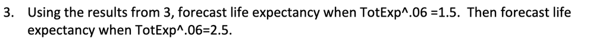

Given the equation $𝑌 = mx + b$ where $m$ is the slope, $b$ is the intercept, and $x, Y$ are points on the line:

```r
x1 = 1.5
x2 = 2.5
b = df.lm2$coefficients[1] #intercept
m = df.lm2$coefficients[2] #slope

pred_1 = m*x1 + b
pred_2 = m*x2 + b

inv_1 = round(pred_1^(1/4.6),2) #inverted prediction
inv_2 = round(pred_2^(1/4.6),2)

print(paste("When TotExp^.06=1.5, Life Expectancy is",inv_1))
```

```
## [1] "When TotExp^.06=1.5, Life Expectancy is 63.31"
```

```r
print(paste("When TotExp^.06=2.5, Life Expectancy is",inv_2))
```

```
## [1] "When TotExp^.06=2.5, Life Expectancy is 86.51"
```

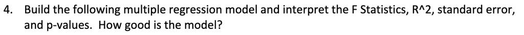

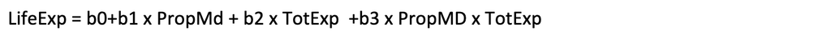

```r
df.lm3 = lm(LifeExp ~ PropMD + TotExp + PropMD*TotExp, df)
summary(df.lm3)
```

```
##
## Call:
## lm(formula = LifeExp ~ PropMD + TotExp + PropMD * TotExp, data = df)
##
## Residuals:
##     Min      1Q  Median      3Q     Max
## -27.320  -4.132   2.098   6.540  13.074
##
## Coefficients:
##                 Estimate Std. Error t value Pr(>|t|)
## (Intercept)    6.277e+01  7.956e-01  78.899  < 2e-16 ***
## PropMD         1.497e+03  2.788e+02   5.371 2.32e-07 ***
## TotExp         7.233e-05  8.982e-06   8.053 9.39e-14 ***
## PropMD:TotExp -6.026e-03  1.472e-03  -4.093 6.35e-05 ***
## ---
## Signif. codes:  0 '***' 0.001 '**' 0.01 '*' 0.05 '.' 0.1 ' ' 1
##
## Residual standard error: 8.765 on 186 degrees of freedom
## Multiple R-squared:  0.3574, Adjusted R-squared:  0.3471
## F-statistic: 34.49 on 3 and 186 DF,  p-value: < 2.2e-16
```

The **R-squared** of 0.35 is low, indicating the combined variables account for 35% of the variability of life expectancy.

The **Standard Error** for the intercept, total expenditures, and proportion of doctors to total expenditures is very low, indicating low variability, while proportion of doctors has high variability.

The **P-value**s are all low, indicating the variables are all significant.

Takeaway - this model does not model the data as well as the previous model, however neither model is reliable at prediction.

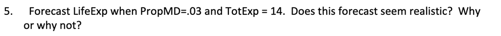

```r
b0 = df.lm3$coefficients[1]
b1 = df.lm3$coefficients[2]
b2 = df.lm3$coefficients[3]
b3 = df.lm3$coefficients[4]

pred = b0 + .03*b1 + 14*b2 + .03*14*b3
print(pred)
```

```
## (Intercept)
##     107.696
```

It does not seem realistic that increasing the percent of doctors can lead to a life expectancy of nearly 108 years!